# RSM Part 1: Designs & Curvature

Author

Dr. Samuel B Fernandes

Published

January 1, 2026

## 1 Motivation: Finding the Optimum

**Scenario:** Optimizing crop fertilization — nitrogen rate, potassium rate, and fertilizer type

- **Step 1 (screening):** Which factors matter? → factorial RCBD
- **Step 2 (optimization):** How much of each? → CCD + second-order model
- **Goal:** Find the combination that **maximizes yield**

**Why factorial designs aren’t enough for optimization:**

- Test discrete levels only (low/high)
- Cannot detect curvature (quadratic effects)
- Cannot interpolate between tested levels

## 2 The Second-Order Model

$$y = \beta_0 + \sum_{i=1}^k \beta_i x_i + \sum_{i=1}^k \beta_{ii} x_i^2 + \sum_{i<j} \beta_{ij} x_i x_j + \epsilon$$

**For two factors:**

$$y = \beta_0 + \beta_1 x_1 + \beta_2 x_2 + \beta_{11} x_1^2 + \beta_{22} x_2^2 + \beta_{12} x_1 x_2 + \epsilon$$

**Terms explained:**

- $\beta_0$: Intercept (response at center point)
- $\beta_1, \beta_2$: Linear effects (slope)
- $\beta_{11}, \beta_{22}$: **Quadratic effects** (curvature)
- $\beta_{12}$: **Interaction** (twist in surface)

**Key insight:** Quadratic terms ($x^2$) capture peaks, valleys, and curvature that factorial designs miss!

## 3 Step 1: Screening — Factorial RCBD

**Before RSM, identify which factors drive the response:**

```r
library(rsm)
library(tidyverse)
library(emmeans)

data <- read.csv("data/RSM_data.csv")
data <- transform(data,
    nitro  = factor(nitro),
    potash = factor(potash),
    ptype  = factor(ptype)
)

aov_screen <- aov(yield ~ block + nitro * ptype * potash, data = data)
anova(aov_screen)
```

|  | Df | Sum Sq | Mean Sq | F value | Pr(>F) |
| --- | --- | --- | --- | --- | --- |
| block | 8 | 16308.000 | 2038.5000 | 5.4335471 | 0.0003500 |
| nitro | 2 | 40035.444 | 20017.7222 | 53.3565052 | 0.0000000 |
| ptype | 1 | 1467.449 | 1467.4491 | 3.9114317 | 0.0578770 |
| potash | 2 | 14461.000 | 7230.5000 | 19.2726329 | 0.0000055 |
| nitro:ptype | 2 | 1481.593 | 740.7963 | 1.9745654 | 0.1576833 |
| nitro:potash | 4 | 10158.689 | 2539.6723 | 6.7694034 | 0.0006071 |
| ptype:potash | 2 | 1006.926 | 503.4630 | 1.3419621 | 0.2776258 |
| nitro:ptype:potash | 4 | 1336.867 | 334.2168 | 0.8908426 | 0.4823429 |
| Residuals | 28 | 10504.740 | 375.1693 | NA | NA |

**Conclusion from screening:**

- Significant interaction: **nitrogen × potassium**
- `ptype` not significant → drop from RSM stage
- Next step: Optimize **nitro** and **potash** as *continuous* factors

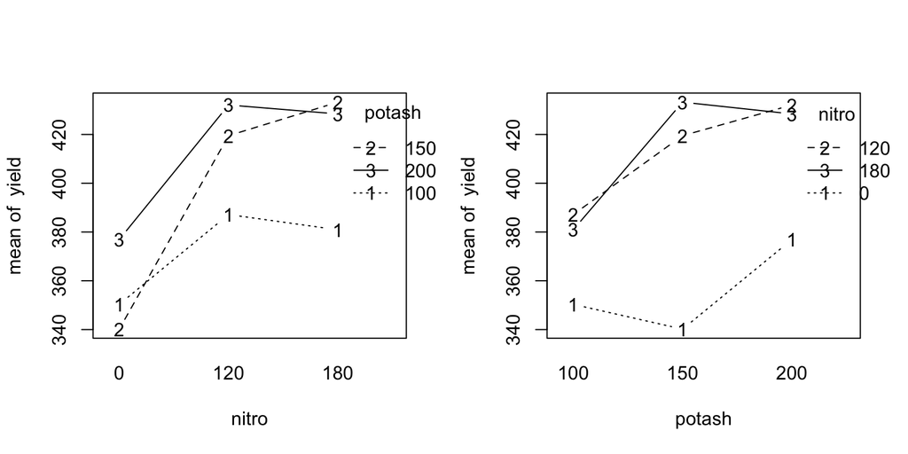

```r
par(mfrow = c(1, 2))
with(data, interaction.plot(nitro, potash, yield, type = "b"))
with(data, interaction.plot(potash, nitro, yield, type = "b"))
```

## 4 Central Composite Design (CCD)

**Structure:** Factorial + axial + center points

```
Factorial points (corners):     (-1, -1), (1, -1), (-1, 1), (1, 1)
Axial points (star):            (-α, 0), (α, 0), (0, -α), (0, α)
Center points (replication):    (0, 0) × n₀
```

**Example CCD for 2 factors:**

- 4 factorial runs (corners of square)
- 4 axial runs (star arms, α = 1.414 for rotatability)
- 3-5 center runs (estimate pure error)

**Total runs:** $2^k + 2k + n_0$ (for k factors)

**Advantages:**

- Efficient: Fewer runs than 3-level factorial ($3^k$ grows fast!)
- Estimates all terms in second-order model
- Rotatable: Same prediction variance at all points equidistant from center

## 5 Step 2: Generate CCD with Factor Coding

Use the `coding =` argument to connect coded units ($x_1$, $x_2$) to natural units:

```r
set.seed(1)
fert <- ccd(
    2, # 2 factors
    n0 = c(3, 3), # 3 center points per block
    alpha = "rotatable",
    coding = list(
        x1 ~ (nitro - 150) / 30, # nitro: center 150, step 30
        x2 ~ (potash - 175) / 25 # potash: center 175, step 25
    )
)
fert
```

| run.order | std.order | x1 | x2 | Block |
| --- | --- | --- | --- | --- |
| 1 | 1 | -1.000000 | -1.000000 | 1 |
| 2 | 4 | 1.000000 | 1.000000 | 1 |
| 3 | 6 | 0.000000 | 0.000000 | 1 |
| 4 | 2 | 1.000000 | -1.000000 | 1 |
| 5 | 5 | 0.000000 | 0.000000 | 1 |
| 6 | 7 | 0.000000 | 0.000000 | 1 |
| 7 | 3 | -1.000000 | 1.000000 | 1 |
| 1 | 4 | 0.000000 | 1.414214 | 2 |
| 2 | 5 | 0.000000 | 0.000000 | 2 |
| 3 | 6 | 0.000000 | 0.000000 | 2 |
| 4 | 1 | -1.414214 | 0.000000 | 2 |
| 5 | 7 | 0.000000 | 0.000000 | 2 |
| 6 | 2 | 1.414214 | 0.000000 | 2 |
| 7 | 3 | 0.000000 | -1.414214 | 2 |

**Why center and scale?**

- Coded units $x_i \in [-1.41,\, 1.41]$ keep coefficients comparable
- Natural units differ in scale (kg/ha vs g/L)
- All RSM analyses should be performed in **coded units**

## 6 Simulate Response Data

```r
# Build data_rsm from the CCD design (fert) with a simulated response
# True function (unknown to experimenter):
#   yield = 45 + 8*x1 + 6*x2 - 5*x1² - 4*x2² + 3*x1*x2 + noise
set.seed(42)
data_rsm <- as_tibble(fert) |>
    mutate(
        yield_gL = 45 +
            8 * x1 + # linear nitrogen effect
            6 * x2 + # linear potassium effect
            -5 * x1^2 + # quadratic N (negative = peak!)
            -4 * x2^2 + # quadratic K (negative = peak!)
            3 * x1 * x2 + # N × K interaction
            rnorm(n(), 0, 2) # experimental error
    )

head(data_rsm[, c("x1", "x2", "yield_gL")])
```

| x1 | x2 | yield_gL |
| --- | --- | --- |
| -1 | -1 | 27.74192 |
| 1 | 1 | 51.87060 |
| 0 | 0 | 45.72626 |
| 1 | -1 | 36.26573 |
| 0 | 0 | 45.80854 |
| 0 | 0 | 44.78775 |

## 7 Three Ways to Specify the Second-Order Model

The `rsm` package provides three equivalent approaches — always prefer **Option 3** (`SO`):

**Option 1 — Base R terms:**

```r
# Explicit: verbose but transparent
lm(terms(
    y ~ nitro + potash +
        nitro:potash +
        I(nitro^2) + I(potash^2),
    keep.order = TRUE
), data = fert)
```

**Option 2 — rsm helper functions:**

```r
# FO = first-order, TWI = two-way interaction,
# PQ = pure quadratic
lm(
    y ~ FO(nitro, potash) +
        TWI(nitro, potash) +
        PQ(nitro, potash),
    data = fert
)
```

**Option 3 — `SO()` shorthand (recommended):**

```r
# SO() = FO + TWI + PQ in one call
lm(y ~ SO(nitro, potash), data = fert)

# With rsm() instead of lm():
# Unlocks canonical analysis & steepest()
rsm(y ~ SO(x1, x2), data = fert)
```

**Note**

`lm()` fits the surface but cannot run `canonical.path()` or `steepest()`. Use `rsm()` for optimization.

## 8 Working with Coded Data

Use `coded.data()` to attach coding formulas to your data frame — then `rsm()` and `code2val()` work automatically:

```r
# Simulate response and add natural-unit columns
set.seed(1)
fert_df <- as_tibble(fert) |>
    mutate(
        y = rnorm(14)^3,
        nitro = x1 * 30 + 150,
        potash = x2 * 25 + 175
    )

# Attach coding formulas
fert_coded <- coded.data(
    fert_df,
    formulas = list(
        x1 ~ (nitro - 150) / 30,
        x2 ~ (potash - 175) / 25
    )
)

# Fit using rsm() — uses coded x1, x2 internally
fert_rs <- rsm(y ~ SO(x1, x2), data = fert_coded)
summary(fert_rs)
```

```
#>
#> Call:
#> rsm(formula = y ~ SO(x1, x2), data = fert_coded)
#>
#>             Estimate Std. Error t value Pr(>|t|)
#> (Intercept) -0.14640    1.25347 -0.1168   0.9099
#> x1          -0.12866    1.08554 -0.1185   0.9086
#> x2           1.52995    1.08554  1.4094   0.1964
#> x1:x2       -1.10383    1.53518 -0.7190   0.4926
#> x1^2         1.57586    1.12986  1.3947   0.2006
#> x2^2        -1.84309    1.12986 -1.6312   0.1415
#>
#> Multiple R-squared:  0.484,  Adjusted R-squared:  0.1615
#> F-statistic: 1.501 on 5 and 8 DF,  p-value: 0.2901
#>
#> Analysis of Variance Table
#>
#> Response: y
#>             Df Sum Sq Mean Sq  F value    Pr(>F)
#> FO(x1, x2)   2 18.858  9.4292   1.0002    0.4095
#> TWI(x1, x2)  1  4.874  4.8738   0.5170    0.4926
#> PQ(x1, x2)   2 47.002 23.5008   2.4929    0.1440
#> Residuals    8 75.417  9.4272
#> Lack of fit  3 74.858 24.9528 223.2045 9.609e-06
#> Pure error   5  0.559  0.1118
#>
#> Stationary point of response surface:
#>        x1        x2
#> 0.1685134 0.3645894
#>
#> Stationary point in original units:
#>    nitro   potash
#> 155.0554 184.1147
#>
#> Eigenanalysis:
#> eigen() decomposition
#> $values
#> [1]  1.662746 -1.929973
#>
#> $vectors
#>          [,1]      [,2]
#> x1 -0.9878339 0.1555126
#> x2  0.1555126 0.9878339
```

## 9 Fit Second-Order Model

```r
# Fit second-order (SO) model using rsm()
model_rsm <- rsm(
    yield_gL ~ SO(x1, x2), # SO() = all quadratic terms
    data = data_rsm
)

summary(model_rsm)
```

```
#>
#> Call:
#> rsm(formula = yield_gL ~ SO(x1, x2), data = data_rsm)
#>
#>             Estimate Std. Error t value  Pr(>|t|)
#> (Intercept) 46.63454    0.78519 59.3926 7.175e-12 ***
#> x1           6.34404    0.68000  9.3295 1.422e-05 ***
#> x2           5.80085    0.68000  8.5307 2.742e-05 ***
#> x1:x2        2.33094    0.96166  2.4239 0.0415980 *
#> x1^2        -5.43326    0.70776 -7.6767 5.869e-05 ***
#> x2^2        -4.57798    0.70776 -6.4683 0.0001945 ***
#> ---
#> Signif. codes:  0 '***' 0.001 '**' 0.01 '*' 0.05 '.' 0.1 ' ' 1
#>
#> Multiple R-squared:  0.9701, Adjusted R-squared:  0.9514
#> F-statistic: 51.87 on 5 and 8 DF,  p-value: 6.974e-06
#>
#> Analysis of Variance Table
#>
#> Response: yield_gL
#>             Df Sum Sq Mean Sq F value    Pr(>F)
#> FO(x1, x2)   2 591.17 295.587 79.9067 5.165e-06
#> TWI(x1, x2)  1  21.73  21.733  5.8752    0.0416
#> PQ(x1, x2)   2 346.55 173.277 46.8424 3.831e-05
#> Residuals    8  29.59   3.699
#> Lack of fit  3   7.17   2.390  0.5330    0.6794
#> Pure error   5  22.42   4.485
#>
#> Stationary point of response surface:
#>        x1        x2
#> 0.7612923 0.8273701
#>
#> Eigenanalysis:
#> eigen() decomposition
#> $values
#> [1] -3.764174 -6.247067
#>
#> $vectors
#>          [,1]       [,2]
#> x1 -0.5725095 -0.8198981
#> x2 -0.8198981  0.5725095
```

**Interpreting output:**

- **Linear terms (FO = First Order):** $\beta_1 x_1 + \beta_2 x_2$
- **Quadratic terms:** $\beta_{11} x_1^2 + \beta_{22} x_2^2$
- **Interaction (TWI = Two-Way Interaction):** $\beta_{12} x_1 x_2$
- **Lack-of-fit test:** Does model adequately fit data? (p > 0.05 = good fit)
- **R²:** Proportion of variation explained

**Decision rules:**

- Quadratic terms significant (p < 0.05) → Curvature detected, proceed with RSM
- Quadratic terms not significant → Linear model adequate, use factorial analysis instead

## 10 Canonical Analysis: Finding the Stationary Point

```r
# Canonical analysis: finds stationary point and classifies surface
canonical_rsm <- summary(model_rsm)

# Stationary point in coded units
stationary_point <- canonical_rsm$canonical$xs
print(stationary_point)
```

```
#>        x1        x2
#> 0.7612923 0.8273701
```

```r
# Back-transform to natural units (nitro centered at 150, step 30;
# potash centered at 175, step 25)
cat("\nOptimal conditions (natural units):\n")
```

```
#>
#> Optimal conditions (natural units):
```

```r
cat("  nitro  =", round(stationary_point["x1"] * 30 + 150, 1), "kg/ha\n")
```

```
#>   nitro  = 172.8 kg/ha
```

```r
cat("  potash =", round(stationary_point["x2"] * 25 + 175, 1), "kg/ha\n")
```

```
#>   potash = 195.7 kg/ha
```

```r
# Predicted yield at optimum
predict(model_rsm, newdata = as.data.frame(t(stationary_point)))
```

```
#>       1
#> 51.4491
```

**Key takeaway:** Stationary point is a **maximum** if all eigenvalues are negative!

| Eigenvalue signs | Surface type |
| --- | --- |
| All $\lambda_i < 0$ | **Maximum** |
| All $\lambda_i > 0$ | **Minimum** |
| Mixed signs | **Saddle point** |

## 11 Visualize: Contour + 3D Surface

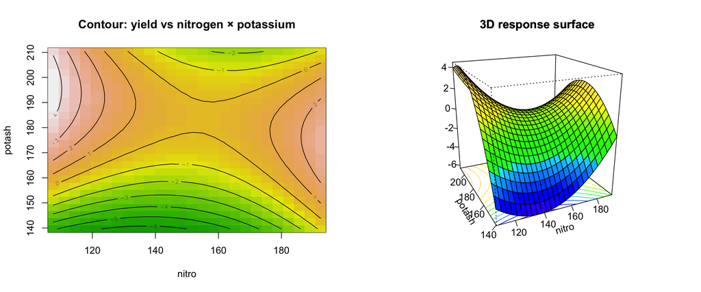

```r
par(mfrow = c(1, 2))

contour(
    fert_rs,
    ~ x1 + x2,
    image = TRUE,
    main  = "Contour: yield vs nitrogen × potassium"
)

persp(
    fert_rs,
    ~ x1 + x2,
    col      = topo.colors(100),
    contours = "colors",
    main     = "3D response surface"
)
```

## 12 Lack-of-Fit Test

**Why center points matter:**

- **Null hypothesis (H₀):** Second-order model adequately fits data
- **Alternative (Hₐ):** Model doesn’t capture all curvature (need higher-order terms or transformation)

```r
# Lack-of-fit test from rsm summary
lof_test <- anova(model_rsm)
print(lof_test)
```

[output not shown]

**Decision:**

- LOF not significant (p > 0.05) → Proceed with optimization
- LOF significant (p < 0.05) → Refit with transformation or add cubic terms

## 13 Steepest Ascent

When the optimum is **not yet reached**, use steepest ascent to move toward it before running a full CCD:

```r
# Compute steepest ascent path from the fitted model
steepest(fert_rs)
```

```
#> Path of steepest ascent from ridge analysis:
```

| dist | x1 | x2 | \| | nitro | potash | \| | yhat |
| --- | --- | --- | --- | --- | --- | --- | --- |
| 0.0 | 0.000 | 0.000 | \| | 150.00 | 175.000 | \| | -0.146 |
| 0.5 | -0.429 | 0.257 | \| | 137.13 | 181.425 | \| | 0.592 |
| 1.0 | -0.938 | 0.347 | \| | 121.86 | 183.675 | \| | 2.029 |
| 1.5 | -1.437 | 0.429 | \| | 106.89 | 185.725 | \| | 4.290 |
| 2.0 | -1.935 | 0.509 | \| | 91.95 | 187.725 | \| | 7.391 |
| 2.5 | -2.430 | 0.588 | \| | 77.10 | 189.700 | \| | 11.311 |
| 3.0 | -2.925 | 0.667 | \| | 62.25 | 191.675 | \| | 16.066 |
| 3.5 | -3.420 | 0.745 | \| | 47.40 | 193.625 | \| | 21.655 |
| 4.0 | -3.915 | 0.824 | \| | 32.55 | 195.600 | \| | 28.081 |
| 4.5 | -4.410 | 0.902 | \| | 17.70 | 197.550 | \| | 35.340 |
| 5.0 | -4.903 | 0.980 | \| | 2.91 | 199.500 | \| | 43.400 |

**How to use the output:**

- Each row is a step along the path of steepest increase
- Columns show coded and natural factor values at each step
- Run confirmatory experiments at the step where response peaks
- Center the next CCD around that point

**Note**

`steepest()` is only available for `rsm()` objects, not plain `lm()` fits.

## 14 Sequential Experimentation Strategy

**RSM is done in phases — never jump straight to CCD:**

**Phase 1: Screening (Factorial RCBD)**

- Identify important factors from many candidates
- Use 2-level factorial
- **Result:** Reduce to 2–3 key factors

**Phase 2: First-Order + Steepest Ascent**

- Add center points to test for curvature
- No curvature → use factorial results
- Curvature detected → follow steepest ascent path to promising region

**Phase 3: Second-Order (CCD)**

- Center CCD in the region found by Phase 2
- Fit `rsm(y ~ SO(x1, x2))`
- Canonical analysis → stationary point + eigenvalues
- `code2val()` → back-transform to natural units
- `steepest()` → if optimum outside region

**Phase 4: Confirmation**

- 3–5 replicates at predicted optimal point
- Verify prediction interval is met

| Phase | Runs | Purpose |
| --- | --- | --- |
| Screening | 10–20 | Identify important factors |
| Steepest ascent | 5–10 | Move toward optimum |
| CCD (2nd-order) | 13–30 | Model curvature, find optimum |
| Confirmation | 3–5 | Validate predictions |

## 15 Practice Exercise

**Note**

**Scenario:** Optimizing crop drying conditions for maximum nutrient retention. Two factors: Drying temperature (50–70°C) and Air velocity (2–4 m/s).

**Your tasks:**

1. Generate a CCD with 4 center points and proper coding formulas
2. Explain why CCD is better than a $3^2$ factorial (9 runs) for this problem
3. If the quadratic temperature term is negative and significant, what does this mean biologically?
4. Sketch what the contour plot might look like if there is a clear optimum
5. How would you use `steepest()` and `code2val()` to report optimal conditions?

## 16 Summary & Key Takeaways

**We covered:**

1. **Screening first** — factorial RCBD to identify which factors to optimize
2. **CCD with coding** — `coding=` in `ccd()`, then `coded.data()` for analysis
3. **Three model syntaxes** — `SO()` wraps `FO() + TWI() + PQ()` in one call
4. **`rsm()` vs `lm()`** — use `rsm()` for canonical analysis and `steepest()`
5. **Visualization** — `contour()` and `persp()` directly on `rsm` objects
6. **Canonical analysis** — eigenvalues classify max / min / saddle
7. **`code2val()`** — convert optimal coded point back to natural units
8. **Steepest ascent** — `steepest()` guides next experiment when optimum is outside region

**Key message:** RSM is a *sequential* strategy. Screen → ascend → fit surface → confirm.

## 17 Canonical Analysis: Finding Stationary Points

**Purpose**: Identify and classify stationary points (where gradient = 0)

**Mathematical Procedure**:

1. Solve gradient equation: $\nabla \hat{Y} = 0$ for $\mathbf{x}_s$ (stationary point)
2. Eigenanalysis of $\mathbf{B}$ matrix → eigenvalues $\lambda_1, \lambda_2, ..., \lambda_k$
3. Classify based on eigenvalue signs:
   - All $\lambda_i < 0$: **Maximum**
   - All $\lambda_i > 0$: **Minimum**
   - Mixed signs: **Saddle point**

**R Implementation**:

```r
library(rsm)

# Fit CCD model
mod_so <- rsm(yield ~ SO(temp, pH), data = fermentation_data)

# Canonical analysis
canonical.path(mod_so)

# Output:
# Analysis of fitted second-order response surface
# x1 = temp, x2 = pH

# Stationary point:
#   x1 (temp)      x2 (pH)
#   0.247          -0.156

# Eigenvalues: -3.24, -2.15
# *** All eigenvalues < 0: Stationary point is a MAXIMUM ***

# Maximum predicted yield: ŷ = 84.2 (at temp = 20.9°C, pH = 6.8)
```

## 18 Eigenvalue Interpretation: Surface Shape

**Case 1: Maximum (all λᵢ < 0)**

- Eigenvalues: λ₁ = -3.2, λ₂ = -1.8
- Surface: **Paraboloid opening downward**
- Interpretation: Optimal factor setting exists within explored region
- Action: Recommend values at stationary point

**Canonical Form**:

$$\hat{Y}_{\text{stat}} = \beta_0 + \sum_i \lambda_i w_i^2$$

where $w_i$ are transformed coordinates

**Confidence**: 95% CI around optimum using std. error

**Case 2: Saddle Point (mixed λᵢ)**

- Eigenvalues: λ₁ = 2.4, λ₂ = -1.6
- Surface: **Saddle** (ridge up one direction, valley another)
- Interpretation: No clear global optimum; trade-offs necessary
- Action: Use ridge analysis to explore surface

**Case 3: Minimum (all λᵢ > 0)**

- Eigenvalues: λ₁ = 2.1, λ₂ = 1.9
- Surface: **Paraboloid opening upward**
- Interpretation: Response decreases in all directions from stationary point
- Action: Move away from stationary point to increase Y

**Practical Interpretation**: Eigenvalues tell you “curvature strength”

- Large |λ|: Sharp curvature (narrow optimum, steep decline)
- Small |λ|: Gentle curvature (flat region, robust to factor changes)

**Example**: λ₁ = -10, λ₂ = -0.2

- Temperature (first eigenvector) has steep optimum: ±0.1°C matters
- pH (second eigenvector) has flat optimum: ±0.5 pH units won’t hurt
- **Recommendation to farmer**: “Control temperature closely, pH flexible”

## 19 Ridge Analysis: Following Constrained Paths

**Purpose**: If stationary point outside experimental region, trace ridge of maximum/minimum response along boundary

**Why Ridge?**: Explores response moving away from center in the most promising direction

**Mathematical Approach**:

```r
# Ridge analysis traces path of maximum predicted response
# as you move outward from center of design

ridge_path <- canonical.path(mod_so,
                             path = "ridge",
                             steps = 10)

# Output shows:
# - Coded factor levels along ridge
# - Predicted response at each step
# - Which direction is optimal (eigenvalue with largest |λ|)
```

**Visual Interpretation**:

```r
# Plot ridge path on contour plot
contour(mod_so,
        x1 ~ x2,
        main = "Ridge Analysis",
        at = seq(70, 85, 2))

# Add ridge path as overlay line
# Points along path show increasing response in that direction
```

## 20 Contour & Perspective Plots for Visualization

**2D Contour Plot**:

```r
library(rsm)

# Generate contour plot with fitted surface
contour(mod_so,
        x1 ~ x2,                    # x1 on y-axis, x2 on x-axis
        main = "Ethanol Yield Response Surface",
        at = seq(78, 86, 1),        # Contour levels
        xlim = c(-1.5, 1.5),
        ylim = c(-1.5, 1.5))

# Add stationary point marker
points(0.247, -0.156,
       pch = 20,
       col = "red",
       cex = 2)
text(0.247, -0.156,
     "Max: 84.2",
     pos = 4,
     cex = 1.2)
```

**3D Perspective Plot**:

```r
# Generate 3D surface plot
persp(mod_so,
      x1 ~ x2,
      zlim = c(75, 87),
      main = "3D Response Surface",
      theta = 45,            # Viewing angle
      phi = 30,              # Elevation angle
      shade = 0.5)           # Surface shading

# Rotate plot for different viewing angles (adjust theta, phi)
```

**Contour Plot Advantages**:

- Clear ellipse shape indicates maximum
- Tight contours: Sharp optimum
- Loose contours: Flat region
- Oriented ellipse: Interactions present
- Easy to identify factor combinations

**Perspective Plot Advantages**:

- Visual intuition about surface shape
- Shows curvature more dramatically
- Useful for presentations
- Harder to read exact values
- Angle matters for interpretation

## 21 Sequential Optimization Strategy

**Core Principle**: Build model complexity progressively; avoid expensive second-order experiments until necessary

**Sequential Strategy**:

1. **Screening Experiment** (1st order)
   - Goal: Identify important factors from many candidates
   - Model: $Y = \beta_0 + \sum \beta_i x_i$ (linear only)
   - Size: ~10-20 runs
2. **First-Order Optimization** (Steepest Ascent)
   - Goal: Move toward optimum region
   - Model: Linear model from screening
   - Size: ~5-10 runs along ridge
   - Output: Identifies promising region
3. **Second-Order Optimization** (CCD, Box-Behnken)
   - Goal: Fine-tune and model curvature
   - Model: Second-order polynomial (this lecture)
   - Size: 15-30 runs in refined region
   - Output: Stationary point, confidence region, ridge if needed
4. **Confirmation Experiments**
   - Goal: Verify predicted optimum in practice
   - Runs: 3-5 replicates at predicted optimal point
   - Outcome: Establish operating conditions

**Cost-Benefit Analysis**:

| Phase | Cost | Benefit | Total Runs |
| --- | --- | --- | --- |
| Screening | Low | Narrows factors | 10-20 |
| 1st-Order | Low | Moves toward optimum | 5-10 |
| 2nd-Order | High | Finds optimum + curvature | 15-30 |
| Confirmation | Low | Validates predictions | 3-5 |
| **Total** | **Moderate** | **Optimized process** | **33-65** |

## 22 Reporting Optimization Results

**Publication Format Example**:

**Methods Section**: > “Response surface methodology with central composite design (k=2, r=3) was employed to optimize drying conditions. A second-order model was fitted to predict moisture content as a function of temperature and air flow. Canonical analysis identified stationary points; ridge analysis was used to explore constrained optimization paths. Optimal settings and 95% confidence intervals were calculated using the rsm package (Lenth & Almeida, 2023).”

**Results Section**: > “The fitted second-order model explained 87% of response variance (R² = 0.87). Canonical analysis revealed a maximum at temperature 28.5°C and airflow 12.3 m/s (predicted moisture: 14.2% ± 1.1%, 95% CI). Eigenanalysis (λ₁ = -2.8, λ₂ = -1.9) confirmed this as a maximum point with sharp curvature in both directions. Temperature showed stronger curvature (|λ₁/λ₂| = 1.47), indicating tighter tolerance needed. Verification experiments at recommended settings confirmed predictions (observed: 14.0%, within CI).”

**Key Elements to Report**:

- Model R² and diagnostic fit statistics
- Location of stationary point (coded and natural units)
- Predicted response ± 95% CI at optimum
- Eigenvalues and interpretation (max/min/saddle)
- Which factors have “sharper” optima (|λ| values)
- Ridge analysis results (if applicable)
- Practical recommendations with confidence bounds
- Verification experiment results (optional but credible)

## 23 Summary: RSM Part 2 Key Concepts

**Canonical Analysis**:

- Finds stationary points via eigenanalysis
- Classifies as maximum, minimum, or saddle
- Provides predicted response + SE at optimum
- 95% CI shows uncertainty in prediction

**Optimization Application**:

- Temperature × pH example → maximum ethanol
- Recommendation: Use optimal T and pH settings
- Confidence: Within ±1°C and ±0.2 pH units

**Ridge Analysis**:

- Follows principal directions of curvature
- Useful when optimum outside experimental region
- Guides toward next experiment location
- Eigenvalues indicate which directions promising

**You Can Now**: Optimize processes using RSM, interpret eigenvalues, visualize surfaces, and recommend factor settings with confidence intervals!

## 24 References

**Primary Text**: - Oehlert, G. W. (2010). *A First Course in Design and Analysis of Experiments*. Chapter 14 (Response surface methods).

**R Packages & Documentation**: - `rsm`: Lenth, R. V., & Almeida, G. (2023). *rsm: Response-Surface Methods*. Canonical analysis, ridge analysis, visualization. - `ggplot2`: Wickham, H. (2016). *ggplot2*. Advanced plotting for contour/surface visualization.